# series tiempo 2

Armand

21 de julio de 2016

# Time Series 2

load data

```r
datos <- read.table("prostate.data", dec = ".")
head(datos)
```

```
##       lcavol  lweight age      lbph svi       lcp gleason pgg45       lpsa
## 1 -0.5798185 2.769459  50 -1.386294   0 -1.386294       6     0 -0.4307829
## 2 -0.9942523 3.319626  58 -1.386294   0 -1.386294       6     0 -0.1625189
## 3 -0.5108256 2.691243  74 -1.386294   0 -1.386294       7    20 -0.1625189
## 4 -1.2039728 3.282789  58 -1.386294   0 -1.386294       6     0 -0.1625189
## 5  0.7514161 3.432373  62 -1.386294   0 -1.386294       6     0  0.3715636
## 6 -1.0498221 3.228826  50 -1.386294   0 -1.386294       6     0  0.7654678
##   train
## 1  TRUE
## 2  TRUE
## 3  TRUE
## 4  TRUE
## 5  TRUE
## 6  TRUE
```

## View the correlaction of data

```r
cor(datos)
```

```
##              lcavol      lweight       age         lbph         svi
## lcavol   1.00000000  0.280521380 0.2249999  0.027349703  0.53884500
## lweight  0.28052138  1.000000000 0.3479691  0.442264399  0.15538490
## age      0.22499988  0.347969112 1.0000000  0.350185896  0.11765804
## lbph     0.02734970  0.442264399 0.3501859  1.000000000 -0.08584324
## svi      0.53884500  0.155384903 0.1176580 -0.085843238  1.00000000
## lcp      0.67531048  0.164537142 0.1276678 -0.006999431  0.67311118
## gleason  0.43241706  0.056882093 0.2688916  0.077820447  0.32041222
## pgg45    0.43365225  0.107353785 0.2761124  0.078460018  0.45764762
## lpsa     0.73446033  0.433319382 0.1695928  0.179809404  0.56621822
## train   -0.04654347 -0.009940658 0.1776155 -0.029939957  0.02679950
##                  lcp     gleason      pgg45        lpsa        train
## lcavol   0.675310484  0.43241706 0.43365225  0.73446033 -0.046543468
## lweight  0.164537142  0.05688209 0.10735379  0.43331938 -0.009940658
## age      0.127667752  0.26889160 0.27611245  0.16959284  0.177615517
## lbph    -0.006999431  0.07782045 0.07846002  0.17980940 -0.029939957
## svi      0.673111185  0.32041222 0.45764762  0.56621822  0.026799505
## lcp      1.000000000  0.51483006 0.63152825  0.54881317 -0.037427296
## gleason  0.514830063  1.00000000 0.75190451  0.36898681 -0.044171456
## pgg45    0.631528246  0.75190451 1.00000000  0.42231586  0.100516371
## lpsa     0.548813175  0.36898681 0.42231586  1.00000000 -0.033889743
## train   -0.037427296 -0.04417146 0.10051637 -0.03388974  1.000000000
```

the best is lcavol vs lpsa

make the regression lcavol vs lpsa

```r
model <- lm(lpsa~lcavol, datos)
model
```

```
##
## Call:
## lm(formula = lpsa ~ lcavol, data = datos)
##
## Coefficients:
## (Intercept)       lcavol
##      1.5073       0.7193
```

Plotting data

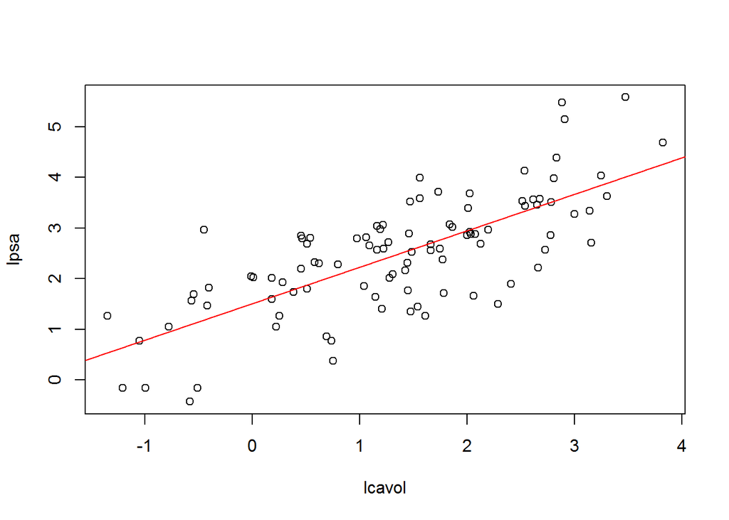

```r
plot(lpsa~lcavol, datos)
abline(model, col="red")
```

red line is the regression line

### making the prediction

```r
pred <- predict(model, data.frame(lcavol=c(0.7,0.41,-0.23)), interval = "confidence")
pred
```

```
##        fit      lwr      upr
## 1 2.010822 1.829324 2.192319
## 2 1.802219 1.598768 2.005670
## 3 1.341854 1.075486 1.608221
```

# Multiple Regression

```r
train <- (datos[datos$train,])
test <- (datos[!datos$train,])
model <- lm(lpsa ~lcavol + lweight,data= train)
model
```

```
##
## Call:
## lm(formula = lpsa ~ lcavol + lweight, data = train)
##
## Coefficients:
## (Intercept)       lcavol      lweight
##     -1.0494       0.6276       0.7384
```

Make the prediction

```r
pred2 <- predict(model, test)
pred2
```

```
##        7        9       10       15       22       25       26       28
## 1.977969 1.076691 1.486298 2.248938 2.828037 1.900271 2.165758 1.553760
##       32       34       36       42       44       48       49       50
## 1.874089 1.369569 2.813674 2.574845 2.939783 2.659998 2.629037 2.351376
##       53       54       55       57       62       64       65       66
## 1.955395 3.328700 3.525913 1.677686 2.950652 3.119780 2.926837 2.698568
##       73       74       80       84       95       97
## 2.537610 2.494617 3.517907 3.465198 3.282954 4.064632
```

Function the calculate the erros

```r
#RSS
RSS <- function(pred, real){
  ss <- sum((real-pred)^2)
  return (ss)

}

#RSE
RSE<- function(pred, real, numPre){

  N <- length(real)-numPre-1
  ss1 <- sqrt((RSS(pred, real))/N)
  return (ss1)

}

#MSE
MSE <- function(pred, real){

  N <- length(real)
  ss <- (1/N)*RSS(pred, real)
  return (ss)


}

#Relative Error

ErrorRelative <- function(pred, real){

  ss <- sum(abs(real-pred))/sum(abs(real))
  return (ss)
}
```

# Evaluating Errors

```r
summary(model)
```

```
##
## Call:
## lm(formula = lpsa ~ lcavol + lweight, data = train)
##
## Residuals:
##      Min       1Q   Median       3Q      Max
## -1.58852 -0.44174  0.01304  0.52613  1.93127
##
## Coefficients:
##             Estimate Std. Error t value Pr(>|t|)
## (Intercept) -1.04944    0.72904  -1.439 0.154885
## lcavol       0.62761    0.07906   7.938 4.14e-11 ***
## lweight      0.73838    0.20613   3.582 0.000658 ***
## ---
## Signif. codes:  0 '***' 0.001 '**' 0.01 '*' 0.05 '.' 0.1 ' ' 1
##
## Residual standard error: 0.7613 on 64 degrees of freedom
## Multiple R-squared:  0.6148, Adjusted R-squared:  0.6027
## F-statistic: 51.06 on 2 and 64 DF,  p-value: 5.54e-14
```

## Errors

```r
RSE(pred2, test$lpsa,2)
```

```
## [1] 0.7397314
```

Note: for this values option confidence in lm can not be activated

```r
MSE(pred2, test$lpsa)
```

```
## [1] 0.4924823
```

```r
ErrorRelative(pred2, test$lpsa)
```

```
## [1] 0.206339
```

# Ridge Regression

```r
suppressMessages(library(glmnet))
#build matraxi for glmnet i.e quit to predict variable
x <- model.matrix(lpsa~.,train)
head(x)
```

```
##   (Intercept)     lcavol  lweight age      lbph svi       lcp gleason
## 1           1 -0.5798185 2.769459  50 -1.386294   0 -1.386294       6
## 2           1 -0.9942523 3.319626  58 -1.386294   0 -1.386294       6
## 3           1 -0.5108256 2.691243  74 -1.386294   0 -1.386294       7
## 4           1 -1.2039728 3.282789  58 -1.386294   0 -1.386294       6
## 5           1  0.7514161 3.432373  62 -1.386294   0 -1.386294       6
## 6           1 -1.0498221 3.228826  50 -1.386294   0 -1.386294       6
##   pgg45 trainTRUE
## 1     0         1
## 2     0         1
## 3    20         1
## 4     0         1
## 5     0         1
## 6     0         1
```

column 1 must be eliminated

```r
x <- model.matrix(lpsa~., train)[,-1]
head(x)
```

```
##       lcavol  lweight age      lbph svi       lcp gleason pgg45 trainTRUE
## 1 -0.5798185 2.769459  50 -1.386294   0 -1.386294       6     0         1
## 2 -0.9942523 3.319626  58 -1.386294   0 -1.386294       6     0         1
## 3 -0.5108256 2.691243  74 -1.386294   0 -1.386294       7    20         1
## 4 -1.2039728 3.282789  58 -1.386294   0 -1.386294       6     0         1
## 5  0.7514161 3.432373  62 -1.386294   0 -1.386294       6     0         1
## 6 -1.0498221 3.228826  50 -1.386294   0 -1.386294       6     0         1
```

extrac the variable to predict

```r
y <- train$lpsa
```

Build testting table

```r
test.table <- model.matrix(lpsa~.,test)[,-1]
```

### Making the ridge regression

```r
ridge.mod <- glmnet(x,y, alpha =0)
```

Plottting the regression

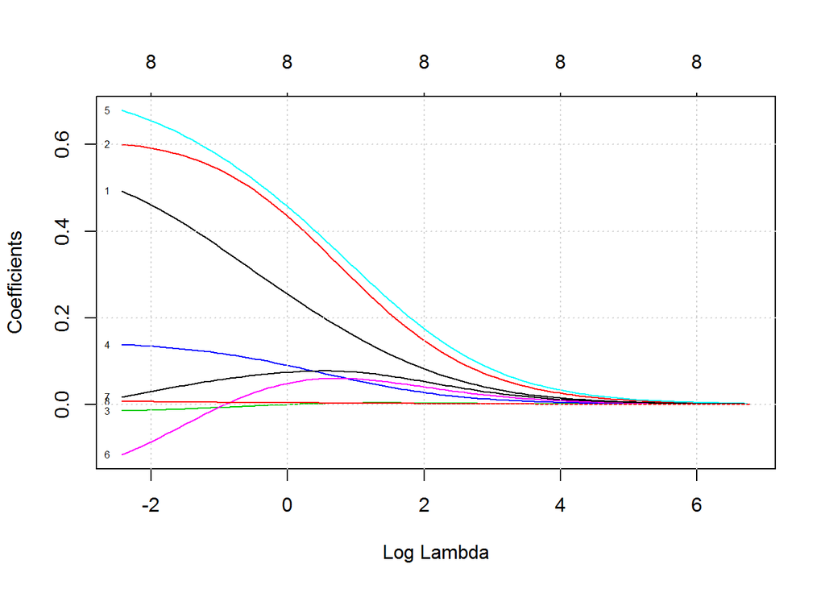

```r
plot(ridge.mod, "lambda", label=T)
panel.first = grid( lty = 3, lwd = 1)
```

### the coef with lambda big

the coefs are small

```r
coef(ridge.mod)[,5]
```

```
##  (Intercept)       lcavol      lweight          age         lbph
## 2.4278507434 0.0014026881 0.0024223514 0.0000718530 0.0004278801
##          svi          lcp      gleason        pgg45    trainTRUE
## 0.0031499320 0.0008282953 0.0011446386 0.0000362673 0.0000000000
```

### the coefs with lambda small

the coefs are bigger

```r
coef(ridge.mod)[,98]
```

```
##  (Intercept)       lcavol      lweight          age         lbph
##  0.055253969  0.479791542  0.597750458 -0.014106340  0.136581860
##          svi          lcp      gleason        pgg45    trainTRUE
##  0.669810195 -0.103975765  0.022681199  0.006778136  0.000000000
```

findinf the optimal lambda with CV

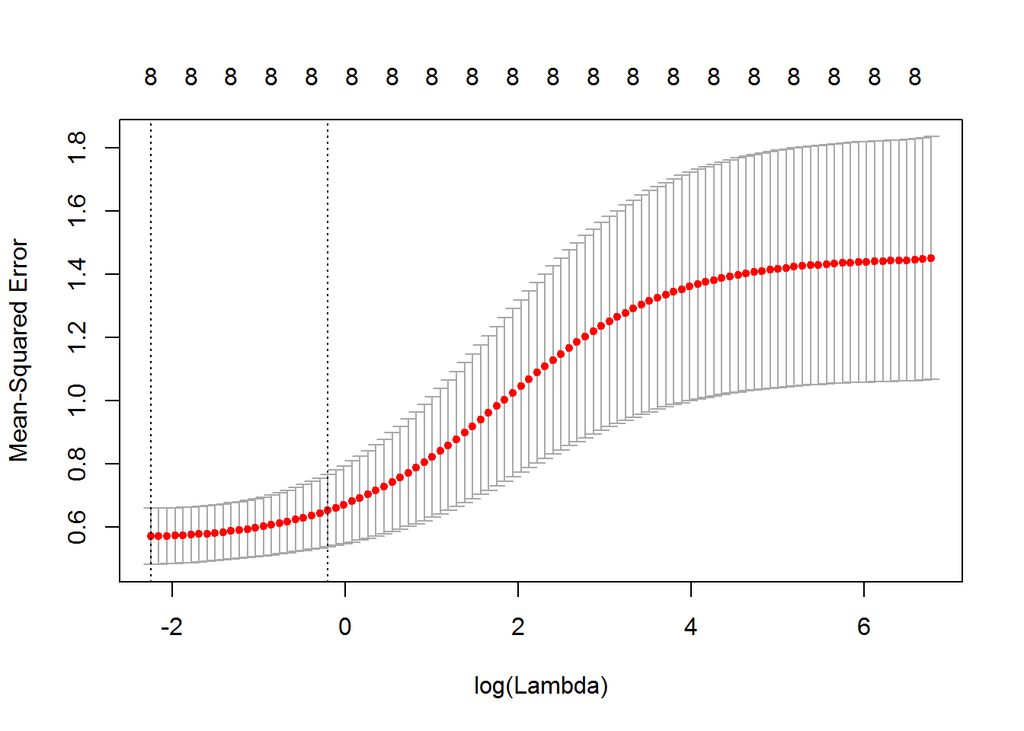

```r
dat.cv <- cv.glmnet(x,y, alpha=0)
plot(dat.cv)
```

we can see the optimal lambda es between -2 to 0

the value of lambda will be

```r
best.lambda <- dat.cv$lambda.min
best.lambda
```

```
## [1] 0.1058615
```

## Prediction with the best lambda

```r
pred <- predict(ridge.mod, s = best.lambda, newx = test.table)
#MSE

MSE(pred, test$lpsa)
```

```
## [1] 0.4921148
```

Relative Error

```r
ErrorRelative(pred, test$lpsa)
```

```
## [1] 0.2039215
```

# Lasso Regression

with the same data

```r
lasso.mod <- glmnet(x,y, alpha = 1)
```

### Plotting the regression

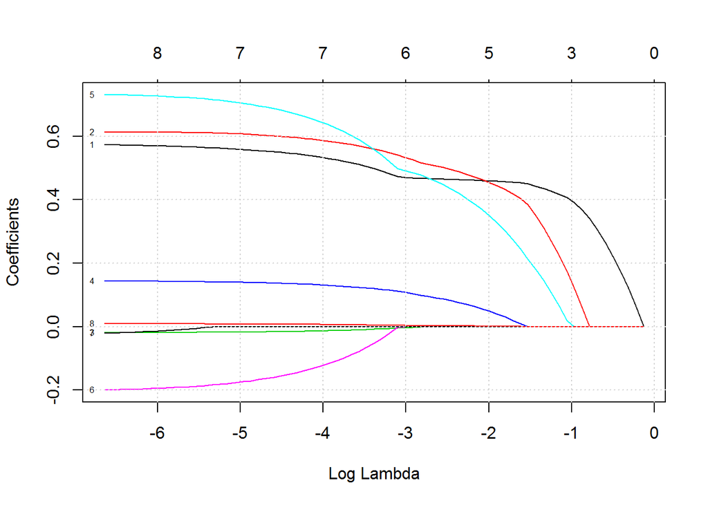

```r
plot(lasso.mod, "lambda", label = T)
panel.first = grid( lty = 3, lwd = 1)
```

### the coef with lambda big

the coefs are small

```r
coef(lasso.mod)[,5]
```

```
## (Intercept)      lcavol     lweight         age        lbph         svi
##   2.1614811   0.2214434   0.0000000   0.0000000   0.0000000   0.0000000
##         lcp     gleason       pgg45   trainTRUE
##   0.0000000   0.0000000   0.0000000   0.0000000
```

### the coefs with lambda small

the coefs are bigger

```r
coef(lasso.mod)[,70]
```

```
##  (Intercept)       lcavol      lweight          age         lbph
##  0.365487212  0.572497177  0.613142882 -0.018665489  0.143682948
##          svi          lcp      gleason        pgg45    trainTRUE
##  0.730802215 -0.199378661 -0.020249923  0.009129164  0.000000000
```

findinf the optimal lambda with CV

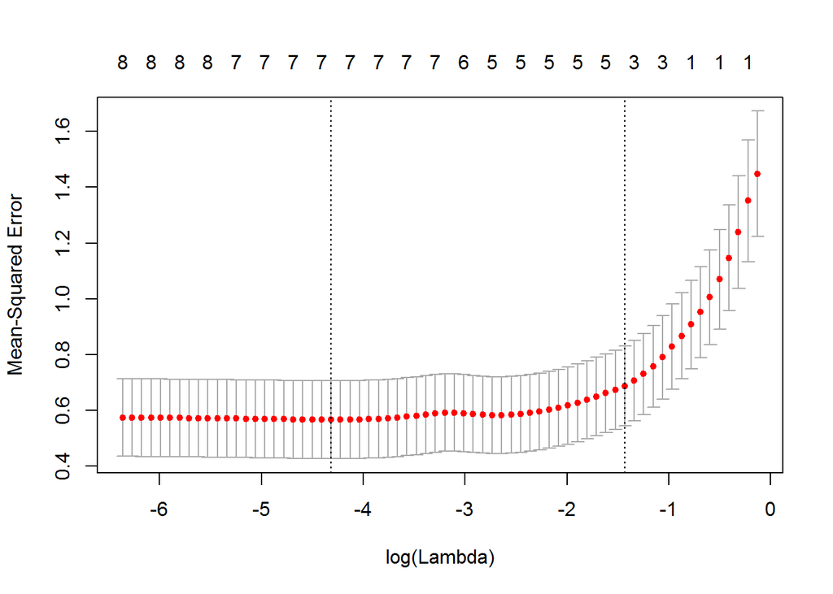

```r
dat.cv <- cv.glmnet(x,y, alpha=1)
plot(dat.cv)
```

we can see the optimal lambda es between -5 to -2

the value of lambda will be

```r
best.lambda <- dat.cv$lambda.min
best.lambda
```

```
## [1] 0.0133582
```

## Prediction with the best lambda

```r
pred <- predict(lasso.mod, s = best.lambda, newx = test.table)
#MSE

MSE(pred, test$lpsa)
```

```
## [1] 0.4931929
```

Relative Error

```r
ErrorRelative(pred, test$lpsa)
```

```
## [1] 0.2010747
```

# Logistic Refression

load data

```r
train <- read.table("C:/Users/Usuario/Desktop/promidat/predictivos/MuestraAprendizajeCredito2500.csv", sep = ";", header = T)
test <- read.table("C:/Users/Usuario/Desktop/promidat/predictivos/MuestraTestCredito2500.csv", sep = ";", header = T)

head(train)
```

```
##   MontoCredito IngresoNeto CoefCreditoAvaluo MontoCuota GradoAcademico
## 1            1           1                 1          1              1
## 2            3           1                 1          1              1
## 3            2           1                 1          1              1
## 4            1           2                 1          1              1
## 5            1           1                 1          1              1
## 6            2           1                 1          1              1
##   BuenPagador
## 1          Si
## 2          Si
## 3          Si
## 4          Si
## 5          Si
## 6          Si
```

Make the logistic model

```r
model <- glm(BuenPagador~., data = train, family = binomial)
model
```

```
##
## Call:  glm(formula = BuenPagador ~ ., family = binomial, data = train)
##
## Coefficients:
##       (Intercept)       MontoCredito        IngresoNeto
##            0.2189            -0.4680             0.9087
## CoefCreditoAvaluo         MontoCuota     GradoAcademico
##            0.1114            -0.4003             0.7856
##
## Degrees of Freedom: 2499 Total (i.e. Null);  2494 Residual
## Null Deviance:       2061
## Residual Deviance: 1853  AIC: 1865
```

Look at the probabilities

```r
prob <- predict(model, test, type ="response")
head(prob)
```

```
##         1         2         3         4         5         6
## 0.7606501 0.7606501 0.5548624 0.4384098 0.4384098 0.7606501
```

To Verify

```r
#packet turn into o and 1, 1 = si
contrasts(train$BuenPagador)
```

```
##    Si
## No  0
## Si  1
```

## Making the Prediction

We must Build the Rules of prediction

```r
prediction <- rep("No", dim(test)[1])
head(prediction)
```

```
## [1] "No" "No" "No" "No" "No" "No"
```

Building the Rules of prediction

```r
prediction[prob > 0.5] = "Si"
actual <- test$BuenPagador
```

Confusion Matrix

```r
MC <- table(actual, prediction)
MC
```

```
##       prediction
## actual   No   Si
##     No   16  329
##     Si   14 2141
```

Error and success

```r
success <- (sum(diag(MC)))/sum(MC)
success
```

```
## [1] 0.8628
```

```r
error <- 1 -success
error
```

```
## [1] 0.1372
```

# Fourier series

load data

```r
datos <- read.csv("C:/Users/Usuario/Desktop/promidat/series de tiempo/1/beer.csv", dec = ".")

colnames(datos)<- c("date", "cant")
head(datos)
```

```
##      date cant
## 1 1956-02 96.0
## 2 1956-03 95.2
## 3 1956-04 77.1
## 4 1956-05 70.9
## 5 1956-06 64.8
## 6 1956-07 70.1
```

Take the log of beer cant

```r
lbeer <- log(datos[,2])
t<- seq(1956, 1995.2, length= length(datos[,2]))
```

Plotting the lbeer data

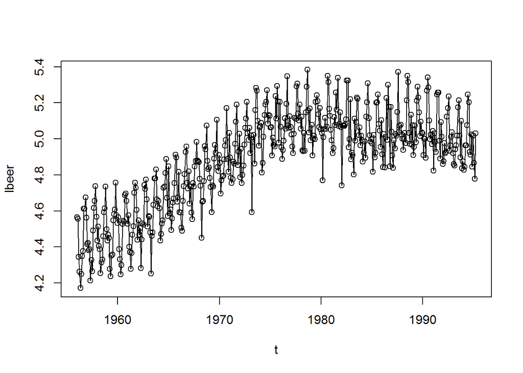

```r
plot(t, lbeer, type = "o")
```

### Regression for the trends

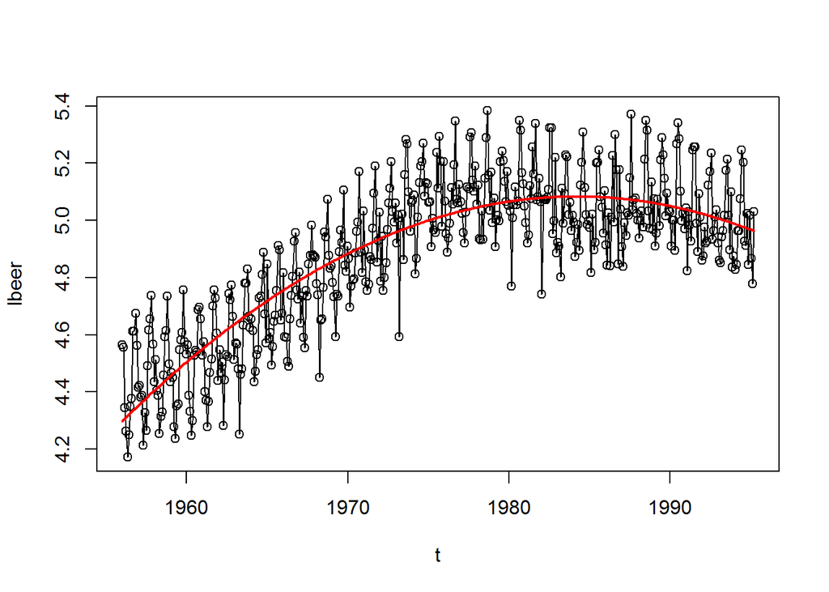

```r
t2 <- t^2
plot(t, lbeer, type = "o")
lines(t, lm(lbeer~t+t2)$fit, col=2, lwd =2)
```

### Fourier for the periods

Addind fouroes series to the model

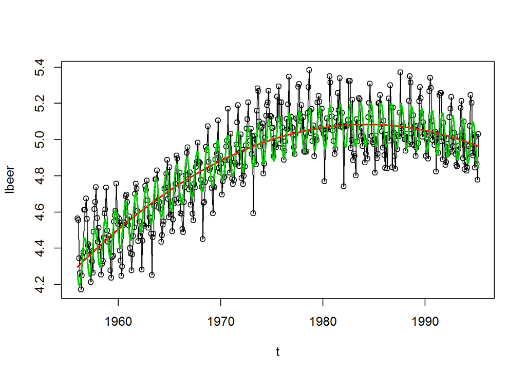

```r
sin.t <- sin(2*pi*t)
cos.t <- cos(2*pi*t)
plot(t, lbeer, type = "o")
lines(t, lm(lbeer~t+t2)$fit, col=2, lwd =2)
lines(t, lm(lbeer~t+t2+sin.t+cos.t)$fit, col = 3, lwd =2)
```

Peridogram

```r
#Convert data to ts
tbeer <- ts(datos[,2], frequency = 12, start =1956)
res <- spec.pgram(tbeer, log = "no")
```

[figure not shown]

```r
res
```

[output not shown]

[output cut: 63 more lines]

```
##
## $taper
## [1] 0.1
##
## $pad
## [1] 0
##
## $detrend
## [1] TRUE
##
## $demean
## [1] FALSE
##
## attr(,"class")
## [1] "spec"
```

order the data to find the max spec

```r
order(res$spec, res$freq, decreasing = T)
```

```
##   [1]  40   1   2 120  80 167 200  41   5  39   6   4 121  44 168 160  79
##  [18]  42  37 207  83  38  82  43  35  56 185 199  78 107 197 108 169 179
##  [35] 102 127  77  74 134 222 178 103 159  86  94 114 122 176  87  92  12
##  [52]  53 175 157 229 124 165 182 180  10  34 237 201  81 132 111 211 135
##  [69]  93 233 198 129 118 146   7 161 123 215  49  96   9 101   8  11 202
##  [86] 106  90  73 223 119  97 131 155 177 239 210 195 218  45 194  57 170
## [103]  75 109  36 196 133  62 158 221 174 116  88 112  72 235 234 144 166
## [120]  50 188 164 141 145 143 128  52 110 126 220 238  71  33  26 125  70
## [137] 115 228 172  54 206 142 184 226 209  55  91  61 113 140 227 138 213
## [154] 187 149 214  21  23  60 186  59 130 100  84  58 139 148 151 224  67
## [171] 104 236  28  46  89 191 205  68 212  32  27  51  47  13 204 163  30
## [188]  18 173 152 171  95 232  16 137  64 240 156 181  15 193 216  25  85
## [205]   3  14  98 183  99  29 230  22  17  20  65 225  24 154  66 117  48
## [222] 189  76 150 105 219 203 217 153 192 208 162  19 231 190  69 136  63
## [239]  31 147
```

```r
max1 <- res$freq[40]
max1
```

```
## [1] 1
```

max2

```r
max2 <- res$freq[2]
max2
```

```
## [1] 0.05
```

max3

```r
max3 <- res$freq[120]
max3
```

```
## [1] 3
```

### Plotting Peridogram

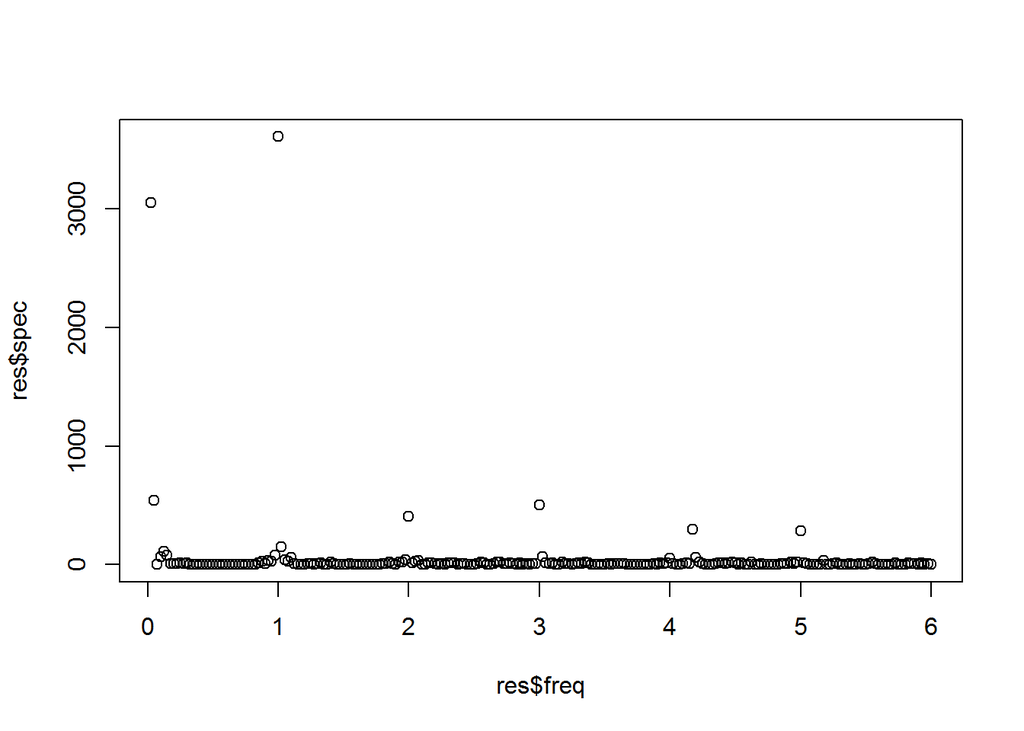

```r
plot(res$freq,res$spec)
```

the first peak ocurre in 1 (from table order)

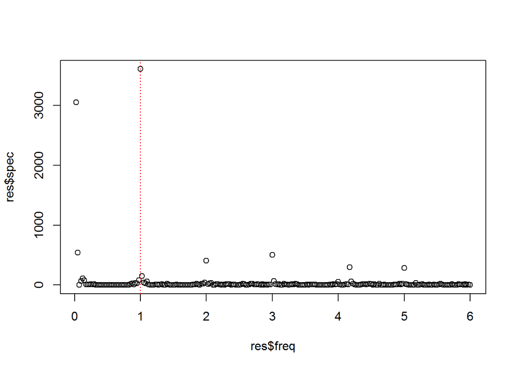

```r
plot(res$freq,res$spec)
abline(v=max1, lty ="dotted", col ="red")
```

```r
# the 12 is from frecuency
period1 <- 12/max1
period1
```

```
## [1] 12
```

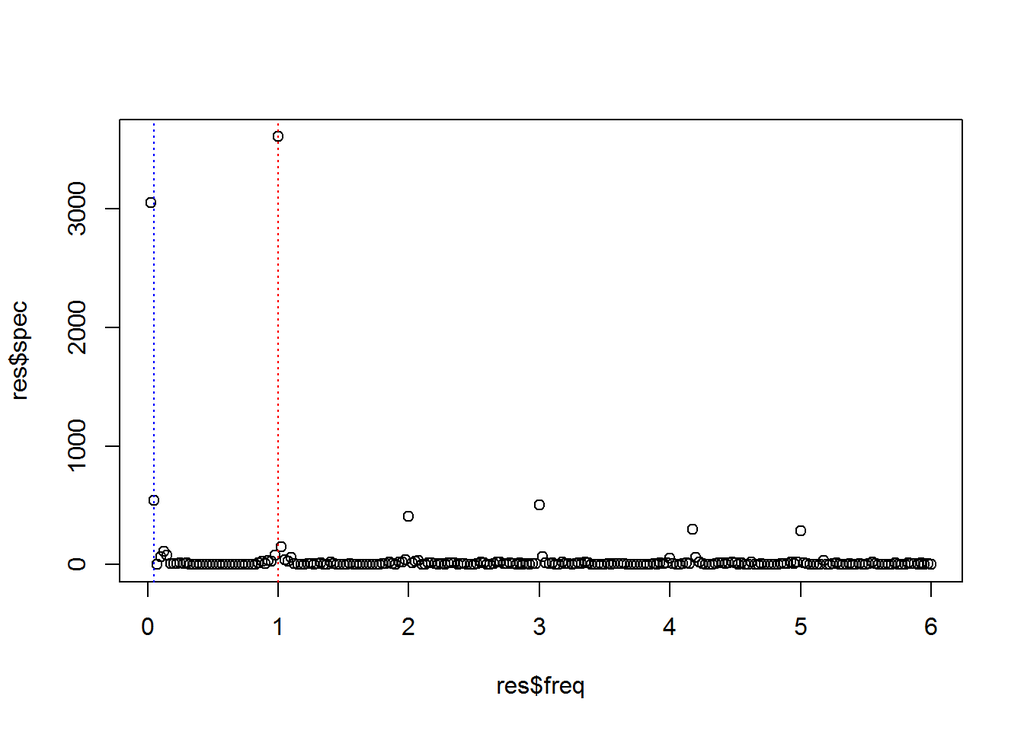

```r
plot(res$freq,res$spec)
abline(v=max1, lty ="dotted", col ="red")
abline(v=max2, lty ="dotted", col ="blue")
```

```r
period2 <- 12/max2
period2
```

```
## [1] 240
```

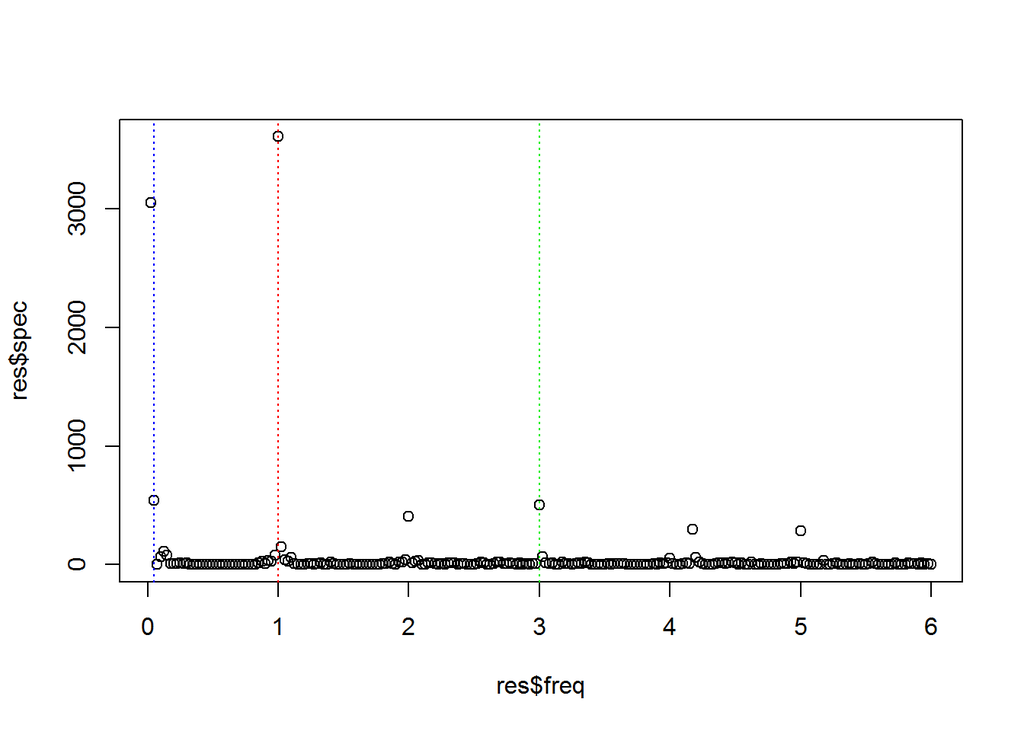

```r
plot(res$freq,res$spec)
abline(v=max1, lty ="dotted", col ="red")
abline(v=max2, lty ="dotted", col ="blue")
abline(v=max3, lty ="dotted", col ="green2")
```

```r
period3 <- 12/max3
period3
```

```
## [1] 4
```